# Risk Factor Analysis

## Outcome Variable

**Outcome Variable:** ever_stunted

## Predictor Variables

**Intervention Variable:** vagbrth

**Adjustment Set:**

- arm
- sex
- W_mage
- meducyrs
- feducyrs
- hhwealth_quart
- W_mhtcm
- W_nrooms
- W_nchldlt5
- brthmon
- W_parity
- impfloor
- impsan
- safeh20
- delta_W_mage
- delta_meducyrs
- delta_feducyrs
- delta_hhwealth_quart
- delta_W_mhtcm
- delta_W_nrooms
- delta_W_nchldlt5
- delta_brthmon
- delta_W_parity
- delta_impfloor
- delta_impsan
- delta_safeh20

## Stratifying Variables

The analysis was stratified on these variable(s):

- agecat
- studyid
- country

## Data Summary

| agecat | studyid | country | vagbrth | ever_stunted | n_cell | n |
| --- | --- | --- | --- | --- | --- | --- |
| 0-24 months (no birth st.) | ki1000108-CMC-V-BCS-2002 | INDIA | 0 | 0 | 3 | 296 |
| 0-24 months (no birth st.) | ki1000108-CMC-V-BCS-2002 | INDIA | 0 | 1 | 17 | 296 |
| 0-24 months (no birth st.) | ki1000108-CMC-V-BCS-2002 | INDIA | 1 | 0 | 25 | 296 |
| 0-24 months (no birth st.) | ki1000108-CMC-V-BCS-2002 | INDIA | 1 | 1 | 251 | 296 |
| 0-24 months (no birth st.) | ki1000108-IRC | INDIA | 0 | 0 | 24 | 360 |
| 0-24 months (no birth st.) | ki1000108-IRC | INDIA | 0 | 1 | 35 | 360 |
| 0-24 months (no birth st.) | ki1000108-IRC | INDIA | 1 | 0 | 123 | 360 |
| 0-24 months (no birth st.) | ki1000108-IRC | INDIA | 1 | 1 | 178 | 360 |
| 0-24 months (no birth st.) | ki1017093b-PROVIDE | BANGLADESH | 0 | 0 | 97 | 634 |
| 0-24 months (no birth st.) | ki1017093b-PROVIDE | BANGLADESH | 0 | 1 | 46 | 634 |
| 0-24 months (no birth st.) | ki1017093b-PROVIDE | BANGLADESH | 1 | 0 | 299 | 634 |
| 0-24 months (no birth st.) | ki1017093b-PROVIDE | BANGLADESH | 1 | 1 | 192 | 634 |
| 0-24 months (no birth st.) | ki1017093c-NIH-Crypto | BANGLADESH | 0 | 0 | 117 | 432 |
| 0-24 months (no birth st.) | ki1017093c-NIH-Crypto | BANGLADESH | 0 | 1 | 58 | 432 |
| 0-24 months (no birth st.) | ki1017093c-NIH-Crypto | BANGLADESH | 1 | 0 | 136 | 432 |
| 0-24 months (no birth st.) | ki1017093c-NIH-Crypto | BANGLADESH | 1 | 1 | 121 | 432 |
| 0-24 months (no birth st.) | ki1066203-TanzaniaChild2 | TANZANIA, UNITED REPUBLIC OF | 0 | 0 | 145 | 2207 |
| 0-24 months (no birth st.) | ki1066203-TanzaniaChild2 | TANZANIA, UNITED REPUBLIC OF | 0 | 1 | 47 | 2207 |
| 0-24 months (no birth st.) | ki1066203-TanzaniaChild2 | TANZANIA, UNITED REPUBLIC OF | 1 | 0 | 1402 | 2207 |
| 0-24 months (no birth st.) | ki1066203-TanzaniaChild2 | TANZANIA, UNITED REPUBLIC OF | 1 | 1 | 613 | 2207 |
| 0-24 months (no birth st.) | ki1119695-PROBIT | BELARUS | 0 | 0 | 1640 | 16742 |
| 0-24 months (no birth st.) | ki1119695-PROBIT | BELARUS | 0 | 1 | 294 | 16742 |
| 0-24 months (no birth st.) | ki1119695-PROBIT | BELARUS | 1 | 0 | 12427 | 16742 |
| 0-24 months (no birth st.) | ki1119695-PROBIT | BELARUS | 1 | 1 | 2381 | 16742 |
| 0-24 months (no birth st.) | ki1126311-ZVITAMBO | ZIMBABWE | 0 | 0 | 731 | 12495 |
| 0-24 months (no birth st.) | ki1126311-ZVITAMBO | ZIMBABWE | 0 | 1 | 356 | 12495 |
| 0-24 months (no birth st.) | ki1126311-ZVITAMBO | ZIMBABWE | 1 | 0 | 7696 | 12495 |
| 0-24 months (no birth st.) | ki1126311-ZVITAMBO | ZIMBABWE | 1 | 1 | 3712 | 12495 |
| 0-24 months (no birth st.) | kiGH5241-JiVitA-3 | BANGLADESH | 0 | 0 | 1957 | 36761 |
| 0-24 months (no birth st.) | kiGH5241-JiVitA-3 | BANGLADESH | 0 | 1 | 396 | 36761 |

[output cut: 78 more lines]

The following strata were considered:

- agecat: 0-24 months (no birth st.), studyid: ki1000108-CMC-V-BCS-2002, country: INDIA
- agecat: 0-24 months (no birth st.), studyid: ki1000108-IRC, country: INDIA
- agecat: 0-24 months (no birth st.), studyid: ki1017093b-PROVIDE, country: BANGLADESH
- agecat: 0-24 months (no birth st.), studyid: ki1017093c-NIH-Crypto, country: BANGLADESH
- agecat: 0-24 months (no birth st.), studyid: ki1066203-TanzaniaChild2, country: TANZANIA, UNITED REPUBLIC OF
- agecat: 0-24 months (no birth st.), studyid: ki1119695-PROBIT, country: BELARUS
- agecat: 0-24 months (no birth st.), studyid: ki1126311-ZVITAMBO, country: ZIMBABWE
- agecat: 0-24 months (no birth st.), studyid: kiGH5241-JiVitA-3, country: BANGLADESH
- agecat: 0-24 months (no birth st.), studyid: kiGH5241-JiVitA-4, country: BANGLADESH
- agecat: 0-6 months (no birth st.), studyid: ki1000108-CMC-V-BCS-2002, country: INDIA
- agecat: 0-6 months (no birth st.), studyid: ki1000108-IRC, country: INDIA
- agecat: 0-6 months (no birth st.), studyid: ki1017093b-PROVIDE, country: BANGLADESH
- agecat: 0-6 months (no birth st.), studyid: ki1017093c-NIH-Crypto, country: BANGLADESH
- agecat: 0-6 months (no birth st.), studyid: ki1066203-TanzaniaChild2, country: TANZANIA, UNITED REPUBLIC OF
- agecat: 0-6 months (no birth st.), studyid: ki1119695-PROBIT, country: BELARUS
- agecat: 0-6 months (no birth st.), studyid: ki1126311-ZVITAMBO, country: ZIMBABWE
- agecat: 0-6 months (no birth st.), studyid: kiGH5241-JiVitA-3, country: BANGLADESH
- agecat: 0-6 months (no birth st.), studyid: kiGH5241-JiVitA-4, country: BANGLADESH
- agecat: 6-24 months, studyid: ki1000108-CMC-V-BCS-2002, country: INDIA
- agecat: 6-24 months, studyid: ki1000108-IRC, country: INDIA
- agecat: 6-24 months, studyid: ki1017093b-PROVIDE, country: BANGLADESH
- agecat: 6-24 months, studyid: ki1017093c-NIH-Crypto, country: BANGLADESH
- agecat: 6-24 months, studyid: ki1066203-TanzaniaChild2, country: TANZANIA, UNITED REPUBLIC OF
- agecat: 6-24 months, studyid: ki1119695-PROBIT, country: BELARUS
- agecat: 6-24 months, studyid: ki1126311-ZVITAMBO, country: ZIMBABWE
- agecat: 6-24 months, studyid: kiGH5241-JiVitA-3, country: BANGLADESH
- agecat: 6-24 months, studyid: kiGH5241-JiVitA-4, country: BANGLADESH

### Dropped Strata

Some strata were dropped due to rare outcomes:

- agecat: 0-24 months (no birth st.), studyid: ki1000108-CMC-V-BCS-2002, country: INDIA
- agecat: 6-24 months, studyid: ki1000108-CMC-V-BCS-2002, country: INDIA

## Methods Detail

We’re interested in the causal parameters $E[Y_a]$ for all values of $a \in \mathcal{A}$. These parameters represent the mean outcome if, possibly contrary to fact, we intervened to set all units to have $A=a$. Under the randomization and positivity assumptions, these are identified by the statistical parameters $\psi_a=E_W[E_{Y|A,W}(Y|A=a,W)]$. In addition, we’re interested in the mean of $Y$, $E[Y]$ under no intervention (the observed mean). We will estimate these parameters by using SuperLearner to fit the relevant likelihood factors – $E_{Y|A,W}(Y|A=a,W)$ and $p(A=a|W)$, and then updating our likelihood fit using a joint TMLE.

For unadjusted analyses ($W=\{\}$), initial likelihoods were estimated using Lrnr_glm to estimate the simple $E(Y|A)$ and Lrnr_mean to estimate $p(A)$. For adjusted analyses, a small library containing Lrnr_glmnet, Lrnr_xgboost, and Lrnr_mean was used.

Having estimated these parameters, we will then use the delta method to estimate relative risks and attributable risks relative to a prespecified baseline level of $A$.

# Results Detail

## Results Plots

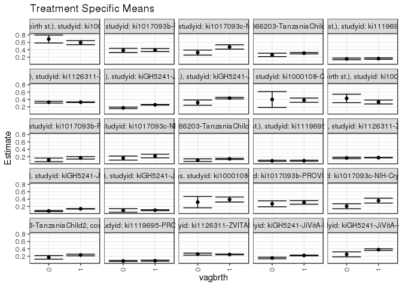

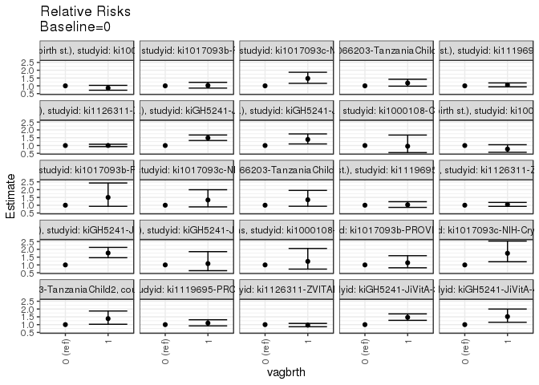

[figure not shown]

[figure not shown]

## Results Table

### Parameter: TSM

| agecat | studyid | country | intervention_level | baseline_level | estimate | ci_lower | ci_upper |
| --- | --- | --- | --- | --- | --- | --- | --- |
| 0-24 months (no birth st.) | ki1000108-IRC | INDIA | 0 | NA | 0.6904818 | 0.5829804 | 0.7979832 |
| 0-24 months (no birth st.) | ki1000108-IRC | INDIA | 1 | NA | 0.5933640 | 0.5381427 | 0.6485853 |
| 0-24 months (no birth st.) | ki1017093b-PROVIDE | BANGLADESH | 0 | NA | 0.3833147 | 0.3263126 | 0.4403169 |
| 0-24 months (no birth st.) | ki1017093b-PROVIDE | BANGLADESH | 1 | NA | 0.3915575 | 0.3500042 | 0.4331109 |
| 0-24 months (no birth st.) | ki1017093c-NIH-Crypto | BANGLADESH | 0 | NA | 0.3231613 | 0.2553430 | 0.3909797 |
| 0-24 months (no birth st.) | ki1017093c-NIH-Crypto | BANGLADESH | 1 | NA | 0.4756889 | 0.4165459 | 0.5348318 |
| 0-24 months (no birth st.) | ki1066203-TanzaniaChild2 | TANZANIA, UNITED REPUBLIC OF | 0 | NA | 0.2607630 | 0.2146397 | 0.3068862 |
| 0-24 months (no birth st.) | ki1066203-TanzaniaChild2 | TANZANIA, UNITED REPUBLIC OF | 1 | NA | 0.3072163 | 0.2872150 | 0.3272177 |
| 0-24 months (no birth st.) | ki1119695-PROBIT | BELARUS | 0 | NA | 0.1520190 | 0.1308999 | 0.1731381 |
| 0-24 months (no birth st.) | ki1119695-PROBIT | BELARUS | 1 | NA | 0.1601379 | 0.1406157 | 0.1796602 |
| 0-24 months (no birth st.) | ki1126311-ZVITAMBO | ZIMBABWE | 0 | NA | 0.3261964 | 0.3024975 | 0.3498954 |
| 0-24 months (no birth st.) | ki1126311-ZVITAMBO | ZIMBABWE | 1 | NA | 0.3274114 | 0.3188473 | 0.3359756 |
| 0-24 months (no birth st.) | kiGH5241-JiVitA-3 | BANGLADESH | 0 | NA | 0.1727751 | 0.1527749 | 0.1927754 |
| 0-24 months (no birth st.) | kiGH5241-JiVitA-3 | BANGLADESH | 1 | NA | 0.2572545 | 0.2493028 | 0.2652063 |
| 0-24 months (no birth st.) | kiGH5241-JiVitA-4 | BANGLADESH | 0 | NA | 0.3156785 | 0.2450005 | 0.3863564 |
| 0-24 months (no birth st.) | kiGH5241-JiVitA-4 | BANGLADESH | 1 | NA | 0.4374421 | 0.4160273 | 0.4588569 |
| 0-6 months (no birth st.) | ki1000108-CMC-V-BCS-2002 | INDIA | 0 | NA | 0.4000000 | 0.1849281 | 0.6150719 |
| 0-6 months (no birth st.) | ki1000108-CMC-V-BCS-2002 | INDIA | 1 | NA | 0.3823529 | 0.3245019 | 0.4402040 |
| 0-6 months (no birth st.) | ki1000108-IRC | INDIA | 0 | NA | 0.4299853 | 0.3158794 | 0.5440912 |
| 0-6 months (no birth st.) | ki1000108-IRC | INDIA | 1 | NA | 0.3319245 | 0.2790154 | 0.3848336 |
| 0-6 months (no birth st.) | ki1017093b-PROVIDE | BANGLADESH | 0 | NA | 0.1116771 | 0.0626592 | 0.1606949 |
| 0-6 months (no birth st.) | ki1017093b-PROVIDE | BANGLADESH | 1 | NA | 0.1676233 | 0.1347253 | 0.2005213 |
| 0-6 months (no birth st.) | ki1017093c-NIH-Crypto | BANGLADESH | 0 | NA | 0.1623118 | 0.1078948 | 0.2167288 |
| 0-6 months (no birth st.) | ki1017093c-NIH-Crypto | BANGLADESH | 1 | NA | 0.2166263 | 0.1671731 | 0.2660794 |
| 0-6 months (no birth st.) | ki1066203-TanzaniaChild2 | TANZANIA, UNITED REPUBLIC OF | 0 | NA | 0.1044760 | 0.0674443 | 0.1415076 |
| 0-6 months (no birth st.) | ki1066203-TanzaniaChild2 | TANZANIA, UNITED REPUBLIC OF | 1 | NA | 0.1409815 | 0.1258727 | 0.1560902 |
| 0-6 months (no birth st.) | ki1119695-PROBIT | BELARUS | 0 | NA | 0.0882795 | 0.0729549 | 0.1036041 |
| 0-6 months (no birth st.) | ki1119695-PROBIT | BELARUS | 1 | NA | 0.0906870 | 0.0769650 | 0.1044089 |
| 0-6 months (no birth st.) | ki1126311-ZVITAMBO | ZIMBABWE | 0 | NA | 0.1650115 | 0.1461413 | 0.1838817 |
| 0-6 months (no birth st.) | ki1126311-ZVITAMBO | ZIMBABWE | 1 | NA | 0.1725715 | 0.1656655 | 0.1794775 |
| 0-6 months (no birth st.) | kiGH5241-JiVitA-3 | BANGLADESH | 0 | NA | 0.0764030 | 0.0624512 | 0.0903548 |
| 0-6 months (no birth st.) | kiGH5241-JiVitA-3 | BANGLADESH | 1 | NA | 0.1347007 | 0.1288738 | 0.1405277 |
| 0-6 months (no birth st.) | kiGH5241-JiVitA-4 | BANGLADESH | 0 | NA | 0.0905978 | 0.0432779 | 0.1379177 |
| 0-6 months (no birth st.) | kiGH5241-JiVitA-4 | BANGLADESH | 1 | NA | 0.0979626 | 0.0850502 | 0.1108751 |
| 6-24 months | ki1000108-IRC | INDIA | 0 | NA | 0.3160266 | 0.1623299 | 0.4697234 |
| 6-24 months | ki1000108-IRC | INDIA | 1 | NA | 0.3877282 | 0.3202633 | 0.4551930 |
| 6-24 months | ki1017093b-PROVIDE | BANGLADESH | 0 | NA | 0.2707728 | 0.1900777 | 0.3514678 |
| 6-24 months | ki1017093b-PROVIDE | BANGLADESH | 1 | NA | 0.3086298 | 0.2601088 | 0.3571508 |
| 6-24 months | ki1017093c-NIH-Crypto | BANGLADESH | 0 | NA | 0.2047769 | 0.1375515 | 0.2720023 |
| 6-24 months | ki1017093c-NIH-Crypto | BANGLADESH | 1 | NA | 0.3573283 | 0.2908837 | 0.4237730 |
| 6-24 months | ki1066203-TanzaniaChild2 | TANZANIA, UNITED REPUBLIC OF | 0 | NA | 0.1677095 | 0.1193819 | 0.2160372 |
| 6-24 months | ki1066203-TanzaniaChild2 | TANZANIA, UNITED REPUBLIC OF | 1 | NA | 0.2320817 | 0.2103718 | 0.2537917 |
| 6-24 months | ki1119695-PROBIT | BELARUS | 0 | NA | 0.0706780 | 0.0565832 | 0.0847729 |
| 6-24 months | ki1119695-PROBIT | BELARUS | 1 | NA | 0.0776238 | 0.0631148 | 0.0921328 |
| 6-24 months | ki1126311-ZVITAMBO | ZIMBABWE | 0 | NA | 0.2556184 | 0.2291155 | 0.2821213 |
| 6-24 months | ki1126311-ZVITAMBO | ZIMBABWE | 1 | NA | 0.2466743 | 0.2367668 | 0.2565818 |
| 6-24 months | kiGH5241-JiVitA-3 | BANGLADESH | 0 | NA | 0.1504169 | 0.1300118 | 0.1708221 |
| 6-24 months | kiGH5241-JiVitA-3 | BANGLADESH | 1 | NA | 0.2205888 | 0.2109565 | 0.2302211 |
| 6-24 months | kiGH5241-JiVitA-4 | BANGLADESH | 0 | NA | 0.2494675 | 0.1820579 | 0.3168772 |
| 6-24 months | kiGH5241-JiVitA-4 | BANGLADESH | 1 | NA | 0.3780106 | 0.3560088 | 0.4000124 |

### Parameter: E(Y)

| agecat | studyid | country | intervention_level | baseline_level | estimate | ci_lower | ci_upper |
| --- | --- | --- | --- | --- | --- | --- | --- |
| 0-24 months (no birth st.) | ki1000108-IRC | INDIA | NA | NA | 0.5916667 | 0.5408218 | 0.6425115 |
| 0-24 months (no birth st.) | ki1017093b-PROVIDE | BANGLADESH | NA | NA | 0.3753943 | 0.3376725 | 0.4131162 |
| 0-24 months (no birth st.) | ki1017093c-NIH-Crypto | BANGLADESH | NA | NA | 0.4143519 | 0.3678455 | 0.4608582 |
| 0-24 months (no birth st.) | ki1066203-TanzaniaChild2 | TANZANIA, UNITED REPUBLIC OF | NA | NA | 0.2990485 | 0.2799429 | 0.3181541 |
| 0-24 months (no birth st.) | ki1119695-PROBIT | BELARUS | NA | NA | 0.1597778 | 0.1408215 | 0.1787342 |
| 0-24 months (no birth st.) | ki1126311-ZVITAMBO | ZIMBABWE | NA | NA | 0.3255702 | 0.3173537 | 0.3337868 |
| 0-24 months (no birth st.) | kiGH5241-JiVitA-3 | BANGLADESH | NA | NA | 0.2535840 | 0.2457754 | 0.2613925 |
| 0-24 months (no birth st.) | kiGH5241-JiVitA-4 | BANGLADESH | NA | NA | 0.4271223 | 0.4066059 | 0.4476388 |
| 0-6 months (no birth st.) | ki1000108-CMC-V-BCS-2002 | INDIA | NA | NA | 0.3835616 | 0.3276935 | 0.4394298 |
| 0-6 months (no birth st.) | ki1000108-IRC | INDIA | NA | NA | 0.3444444 | 0.2952897 | 0.3935992 |
| 0-6 months (no birth st.) | ki1017093b-PROVIDE | BANGLADESH | NA | NA | 0.1593060 | 0.1307970 | 0.1878149 |
| 0-6 months (no birth st.) | ki1017093c-NIH-Crypto | BANGLADESH | NA | NA | 0.1944444 | 0.1570803 | 0.2318086 |
| 0-6 months (no birth st.) | ki1066203-TanzaniaChild2 | TANZANIA, UNITED REPUBLIC OF | NA | NA | 0.1381966 | 0.1237955 | 0.1525978 |
| 0-6 months (no birth st.) | ki1119695-PROBIT | BELARUS | NA | NA | 0.0912784 | 0.0781588 | 0.1043979 |
| 0-6 months (no birth st.) | ki1126311-ZVITAMBO | ZIMBABWE | NA | NA | 0.1709936 | 0.1643878 | 0.1775994 |
| 0-6 months (no birth st.) | kiGH5241-JiVitA-3 | BANGLADESH | NA | NA | 0.1309789 | 0.1253283 | 0.1366296 |
| 0-6 months (no birth st.) | kiGH5241-JiVitA-4 | BANGLADESH | NA | NA | 0.0978125 | 0.0850264 | 0.1105986 |
| 6-24 months | ki1000108-IRC | INDIA | NA | NA | 0.3771186 | 0.3151523 | 0.4390850 |
| 6-24 months | ki1017093b-PROVIDE | BANGLADESH | NA | NA | 0.2997812 | 0.2577294 | 0.3418330 |
| 6-24 months | ki1017093c-NIH-Crypto | BANGLADESH | NA | NA | 0.2923077 | 0.2427834 | 0.3418319 |
| 6-24 months | ki1066203-TanzaniaChild2 | TANZANIA, UNITED REPUBLIC OF | NA | NA | 0.2243995 | 0.2038353 | 0.2449637 |
| 6-24 months | ki1119695-PROBIT | BELARUS | NA | NA | 0.0768510 | 0.0628857 | 0.0908164 |
| 6-24 months | ki1126311-ZVITAMBO | ZIMBABWE | NA | NA | 0.2458186 | 0.2363185 | 0.2553186 |
| 6-24 months | kiGH5241-JiVitA-3 | BANGLADESH | NA | NA | 0.2166156 | 0.2072830 | 0.2259483 |
| 6-24 months | kiGH5241-JiVitA-4 | BANGLADESH | NA | NA | 0.3672091 | 0.3463329 | 0.3880854 |

### Parameter: RR

| agecat | studyid | country | intervention_level | baseline_level | estimate | ci_lower | ci_upper |
| --- | --- | --- | --- | --- | --- | --- | --- |
| 0-24 months (no birth st.) | ki1000108-IRC | INDIA | 0 | 0 | 1.0000000 | 1.0000000 | 1.000000 |
| 0-24 months (no birth st.) | ki1000108-IRC | INDIA | 1 | 0 | 0.8593477 | 0.7169596 | 1.030014 |
| 0-24 months (no birth st.) | ki1017093b-PROVIDE | BANGLADESH | 0 | 0 | 1.0000000 | 1.0000000 | 1.000000 |
| 0-24 months (no birth st.) | ki1017093b-PROVIDE | BANGLADESH | 1 | 0 | 1.0215040 | 0.8533289 | 1.222823 |
| 0-24 months (no birth st.) | ki1017093c-NIH-Crypto | BANGLADESH | 0 | 0 | 1.0000000 | 1.0000000 | 1.000000 |
| 0-24 months (no birth st.) | ki1017093c-NIH-Crypto | BANGLADESH | 1 | 0 | 1.4719857 | 1.1595830 | 1.868553 |
| 0-24 months (no birth st.) | ki1066203-TanzaniaChild2 | TANZANIA, UNITED REPUBLIC OF | 0 | 0 | 1.0000000 | 1.0000000 | 1.000000 |
| 0-24 months (no birth st.) | ki1066203-TanzaniaChild2 | TANZANIA, UNITED REPUBLIC OF | 1 | 0 | 1.1781439 | 0.9766818 | 1.421162 |
| 0-24 months (no birth st.) | ki1119695-PROBIT | BELARUS | 0 | 0 | 1.0000000 | 1.0000000 | 1.000000 |
| 0-24 months (no birth st.) | ki1119695-PROBIT | BELARUS | 1 | 0 | 1.0534075 | 0.9350103 | 1.186797 |
| 0-24 months (no birth st.) | ki1126311-ZVITAMBO | ZIMBABWE | 0 | 0 | 1.0000000 | 1.0000000 | 1.000000 |
| 0-24 months (no birth st.) | ki1126311-ZVITAMBO | ZIMBABWE | 1 | 0 | 1.0037248 | 0.9296339 | 1.083721 |
| 0-24 months (no birth st.) | kiGH5241-JiVitA-3 | BANGLADESH | 0 | 0 | 1.0000000 | 1.0000000 | 1.000000 |
| 0-24 months (no birth st.) | kiGH5241-JiVitA-3 | BANGLADESH | 1 | 0 | 1.4889556 | 1.3231671 | 1.675517 |
| 0-24 months (no birth st.) | kiGH5241-JiVitA-4 | BANGLADESH | 0 | 0 | 1.0000000 | 1.0000000 | 1.000000 |
| 0-24 months (no birth st.) | kiGH5241-JiVitA-4 | BANGLADESH | 1 | 0 | 1.3857205 | 1.1015175 | 1.743251 |
| 0-6 months (no birth st.) | ki1000108-CMC-V-BCS-2002 | INDIA | 0 | 0 | 1.0000000 | 1.0000000 | 1.000000 |
| 0-6 months (no birth st.) | ki1000108-CMC-V-BCS-2002 | INDIA | 1 | 0 | 0.9558824 | 0.5467942 | 1.671033 |
| 0-6 months (no birth st.) | ki1000108-IRC | INDIA | 0 | 0 | 1.0000000 | 1.0000000 | 1.000000 |
| 0-6 months (no birth st.) | ki1000108-IRC | INDIA | 1 | 0 | 0.7719438 | 0.5669213 | 1.051111 |
| 0-6 months (no birth st.) | ki1017093b-PROVIDE | BANGLADESH | 0 | 0 | 1.0000000 | 1.0000000 | 1.000000 |
| 0-6 months (no birth st.) | ki1017093b-PROVIDE | BANGLADESH | 1 | 0 | 1.5009644 | 0.9288406 | 2.425491 |
| 0-6 months (no birth st.) | ki1017093c-NIH-Crypto | BANGLADESH | 0 | 0 | 1.0000000 | 1.0000000 | 1.000000 |
| 0-6 months (no birth st.) | ki1017093c-NIH-Crypto | BANGLADESH | 1 | 0 | 1.3346303 | 0.8935967 | 1.993336 |
| 0-6 months (no birth st.) | ki1066203-TanzaniaChild2 | TANZANIA, UNITED REPUBLIC OF | 0 | 0 | 1.0000000 | 1.0000000 | 1.000000 |
| 0-6 months (no birth st.) | ki1066203-TanzaniaChild2 | TANZANIA, UNITED REPUBLIC OF | 1 | 0 | 1.3494150 | 0.9333921 | 1.950864 |
| 0-6 months (no birth st.) | ki1119695-PROBIT | BELARUS | 0 | 0 | 1.0000000 | 1.0000000 | 1.000000 |
| 0-6 months (no birth st.) | ki1119695-PROBIT | BELARUS | 1 | 0 | 1.0272712 | 0.8612354 | 1.225317 |
| 0-6 months (no birth st.) | ki1126311-ZVITAMBO | ZIMBABWE | 0 | 0 | 1.0000000 | 1.0000000 | 1.000000 |
| 0-6 months (no birth st.) | ki1126311-ZVITAMBO | ZIMBABWE | 1 | 0 | 1.0458150 | 0.9269691 | 1.179898 |
| 0-6 months (no birth st.) | kiGH5241-JiVitA-3 | BANGLADESH | 0 | 0 | 1.0000000 | 1.0000000 | 1.000000 |
| 0-6 months (no birth st.) | kiGH5241-JiVitA-3 | BANGLADESH | 1 | 0 | 1.7630298 | 1.4629281 | 2.124693 |
| 0-6 months (no birth st.) | kiGH5241-JiVitA-4 | BANGLADESH | 0 | 0 | 1.0000000 | 1.0000000 | 1.000000 |
| 0-6 months (no birth st.) | kiGH5241-JiVitA-4 | BANGLADESH | 1 | 0 | 1.0812914 | 0.6315111 | 1.851418 |
| 6-24 months | ki1000108-IRC | INDIA | 0 | 0 | 1.0000000 | 1.0000000 | 1.000000 |
| 6-24 months | ki1000108-IRC | INDIA | 1 | 0 | 1.2268844 | 0.7322820 | 2.055554 |
| 6-24 months | ki1017093b-PROVIDE | BANGLADESH | 0 | 0 | 1.0000000 | 1.0000000 | 1.000000 |
| 6-24 months | ki1017093b-PROVIDE | BANGLADESH | 1 | 0 | 1.1398110 | 0.8161860 | 1.591756 |
| 6-24 months | ki1017093c-NIH-Crypto | BANGLADESH | 0 | 0 | 1.0000000 | 1.0000000 | 1.000000 |
| 6-24 months | ki1017093c-NIH-Crypto | BANGLADESH | 1 | 0 | 1.7449638 | 1.2034570 | 2.530127 |
| 6-24 months | ki1066203-TanzaniaChild2 | TANZANIA, UNITED REPUBLIC OF | 0 | 0 | 1.0000000 | 1.0000000 | 1.000000 |
| 6-24 months | ki1066203-TanzaniaChild2 | TANZANIA, UNITED REPUBLIC OF | 1 | 0 | 1.3838314 | 1.0229841 | 1.871964 |
| 6-24 months | ki1119695-PROBIT | BELARUS | 0 | 0 | 1.0000000 | 1.0000000 | 1.000000 |
| 6-24 months | ki1119695-PROBIT | BELARUS | 1 | 0 | 1.0982733 | 0.9195832 | 1.311686 |
| 6-24 months | ki1126311-ZVITAMBO | ZIMBABWE | 0 | 0 | 1.0000000 | 1.0000000 | 1.000000 |
| 6-24 months | ki1126311-ZVITAMBO | ZIMBABWE | 1 | 0 | 0.9650100 | 0.8636754 | 1.078234 |
| 6-24 months | kiGH5241-JiVitA-3 | BANGLADESH | 0 | 0 | 1.0000000 | 1.0000000 | 1.000000 |
| 6-24 months | kiGH5241-JiVitA-3 | BANGLADESH | 1 | 0 | 1.4665155 | 1.2741076 | 1.687980 |
| 6-24 months | kiGH5241-JiVitA-4 | BANGLADESH | 0 | 0 | 1.0000000 | 1.0000000 | 1.000000 |
| 6-24 months | kiGH5241-JiVitA-4 | BANGLADESH | 1 | 0 | 1.5152698 | 1.1485639 | 1.999055 |

### Parameter: PAR

| agecat | studyid | country | intervention_level | baseline_level | estimate | ci_lower | ci_upper |
| --- | --- | --- | --- | --- | --- | --- | --- |
| 0-24 months (no birth st.) | ki1000108-IRC | INDIA | 0 | NA | -0.0988151 | -0.1980002 | 0.0003699 |
| 0-24 months (no birth st.) | ki1017093b-PROVIDE | BANGLADESH | 0 | NA | -0.0079204 | -0.0595088 | 0.0436680 |
| 0-24 months (no birth st.) | ki1017093c-NIH-Crypto | BANGLADESH | 0 | NA | 0.0911905 | 0.0384354 | 0.1439456 |
| 0-24 months (no birth st.) | ki1066203-TanzaniaChild2 | TANZANIA, UNITED REPUBLIC OF | 0 | NA | 0.0382855 | -0.0067768 | 0.0833478 |
| 0-24 months (no birth st.) | ki1119695-PROBIT | BELARUS | 0 | NA | 0.0077588 | -0.0087534 | 0.0242711 |
| 0-24 months (no birth st.) | ki1126311-ZVITAMBO | ZIMBABWE | 0 | NA | -0.0006262 | -0.0233224 | 0.0220700 |
| 0-24 months (no birth st.) | kiGH5241-JiVitA-3 | BANGLADESH | 0 | NA | 0.0808088 | 0.0608898 | 0.1007278 |
| 0-24 months (no birth st.) | kiGH5241-JiVitA-4 | BANGLADESH | 0 | NA | 0.1114439 | 0.0439803 | 0.1789075 |
| 0-6 months (no birth st.) | ki1000108-CMC-V-BCS-2002 | INDIA | 0 | NA | -0.0164384 | -0.2239010 | 0.1910243 |
| 0-6 months (no birth st.) | ki1000108-IRC | INDIA | 0 | NA | -0.0855408 | -0.1891821 | 0.0181004 |
| 0-6 months (no birth st.) | ki1017093b-PROVIDE | BANGLADESH | 0 | NA | 0.0476289 | 0.0024251 | 0.0928328 |
| 0-6 months (no birth st.) | ki1017093c-NIH-Crypto | BANGLADESH | 0 | NA | 0.0321326 | -0.0112238 | 0.0754890 |
| 0-6 months (no birth st.) | ki1066203-TanzaniaChild2 | TANZANIA, UNITED REPUBLIC OF | 0 | NA | 0.0337207 | -0.0022063 | 0.0696476 |
| 0-6 months (no birth st.) | ki1119695-PROBIT | BELARUS | 0 | NA | 0.0029989 | -0.0107848 | 0.0167826 |
| 0-6 months (no birth st.) | ki1126311-ZVITAMBO | ZIMBABWE | 0 | NA | 0.0059821 | -0.0121515 | 0.0241157 |
| 0-6 months (no birth st.) | kiGH5241-JiVitA-3 | BANGLADESH | 0 | NA | 0.0545760 | 0.0404382 | 0.0687137 |
| 0-6 months (no birth st.) | kiGH5241-JiVitA-4 | BANGLADESH | 0 | NA | 0.0072147 | -0.0368389 | 0.0512683 |
| 6-24 months | ki1000108-IRC | INDIA | 0 | NA | 0.0610920 | -0.0817621 | 0.2039461 |
| 6-24 months | ki1017093b-PROVIDE | BANGLADESH | 0 | NA | 0.0290084 | -0.0418263 | 0.0998432 |
| 6-24 months | ki1017093c-NIH-Crypto | BANGLADESH | 0 | NA | 0.0875308 | 0.0330260 | 0.1420355 |
| 6-24 months | ki1066203-TanzaniaChild2 | TANZANIA, UNITED REPUBLIC OF | 0 | NA | 0.0566900 | 0.0094379 | 0.1039420 |
| 6-24 months | ki1119695-PROBIT | BELARUS | 0 | NA | 0.0061730 | -0.0055256 | 0.0178716 |
| 6-24 months | ki1126311-ZVITAMBO | ZIMBABWE | 0 | NA | -0.0097999 | -0.0352963 | 0.0156966 |
| 6-24 months | kiGH5241-JiVitA-3 | BANGLADESH | 0 | NA | 0.0661987 | 0.0455784 | 0.0868190 |
| 6-24 months | kiGH5241-JiVitA-4 | BANGLADESH | 0 | NA | 0.1177416 | 0.0527620 | 0.1827212 |

### Parameter: PAF

| agecat | studyid | country | intervention_level | baseline_level | estimate | ci_lower | ci_upper |
| --- | --- | --- | --- | --- | --- | --- | --- |
| 0-24 months (no birth st.) | ki1000108-IRC | INDIA | 0 | NA | -0.1670115 | -0.3494086 | -0.0092687 |
| 0-24 months (no birth st.) | ki1017093b-PROVIDE | BANGLADESH | 0 | NA | -0.0210989 | -0.1687386 | 0.1078904 |
| 0-24 months (no birth st.) | ki1017093c-NIH-Crypto | BANGLADESH | 0 | NA | 0.2200799 | 0.0810136 | 0.3381019 |
| 0-24 months (no birth st.) | ki1066203-TanzaniaChild2 | TANZANIA, UNITED REPUBLIC OF | 0 | NA | 0.1280244 | -0.0352102 | 0.2655198 |
| 0-24 months (no birth st.) | ki1119695-PROBIT | BELARUS | 0 | NA | 0.0485602 | -0.0588655 | 0.1450871 |
| 0-24 months (no birth st.) | ki1126311-ZVITAMBO | ZIMBABWE | 0 | NA | -0.0019234 | -0.0741210 | 0.0654214 |
| 0-24 months (no birth st.) | kiGH5241-JiVitA-3 | BANGLADESH | 0 | NA | 0.3186669 | 0.2367751 | 0.3917720 |
| 0-24 months (no birth st.) | kiGH5241-JiVitA-4 | BANGLADESH | 0 | NA | 0.2609180 | 0.0840776 | 0.4036151 |
| 0-6 months (no birth st.) | ki1000108-CMC-V-BCS-2002 | INDIA | 0 | NA | -0.0428571 | -0.7517776 | 0.3791729 |
| 0-6 months (no birth st.) | ki1000108-IRC | INDIA | 0 | NA | -0.2483444 | -0.5918537 | 0.0210384 |
| 0-6 months (no birth st.) | ki1017093b-PROVIDE | BANGLADESH | 0 | NA | 0.2989777 | -0.0442286 | 0.5293825 |
| 0-6 months (no birth st.) | ki1017093c-NIH-Crypto | BANGLADESH | 0 | NA | 0.1652536 | -0.0892652 | 0.3603012 |
| 0-6 months (no birth st.) | ki1066203-TanzaniaChild2 | TANZANIA, UNITED REPUBLIC OF | 0 | NA | 0.2440049 | -0.0636131 | 0.4626537 |
| 0-6 months (no birth st.) | ki1119695-PROBIT | BELARUS | 0 | NA | 0.0328544 | -0.1287150 | 0.1712961 |
| 0-6 months (no birth st.) | ki1126311-ZVITAMBO | ZIMBABWE | 0 | NA | 0.0349843 | -0.0770172 | 0.1353386 |
| 0-6 months (no birth st.) | kiGH5241-JiVitA-3 | BANGLADESH | 0 | NA | 0.4166774 | 0.3013685 | 0.5129546 |
| 0-6 months (no birth st.) | kiGH5241-JiVitA-4 | BANGLADESH | 0 | NA | 0.0737604 | -0.5083083 | 0.4312040 |
| 6-24 months | ki1000108-IRC | INDIA | 0 | NA | 0.1619968 | -0.3169180 | 0.4667478 |
| 6-24 months | ki1017093b-PROVIDE | BANGLADESH | 0 | NA | 0.0967653 | -0.1730053 | 0.3044934 |
| 6-24 months | ki1017093c-NIH-Crypto | BANGLADESH | 0 | NA | 0.2994473 | 0.0879003 | 0.4619294 |
| 6-24 months | ki1066203-TanzaniaChild2 | TANZANIA, UNITED REPUBLIC OF | 0 | NA | 0.2526296 | 0.0127825 | 0.4342052 |
| 6-24 months | ki1119695-PROBIT | BELARUS | 0 | NA | 0.0803243 | -0.0789338 | 0.2160748 |
| 6-24 months | ki1126311-ZVITAMBO | ZIMBABWE | 0 | NA | -0.0398662 | -0.1490819 | 0.0589689 |
| 6-24 months | kiGH5241-JiVitA-3 | BANGLADESH | 0 | NA | 0.3056044 | 0.2063272 | 0.3924635 |
| 6-24 months | kiGH5241-JiVitA-4 | BANGLADESH | 0 | NA | 0.3206391 | 0.1182761 | 0.4765582 |